# R4_Internal_Lab

### The data set has information about features of silhouette extracted from the images of different cars

Four "Corgie" model vehicles were used for the experiment: a double decker bus, Cheverolet van, Saab 9000 and an Opel Manta 400 cars. This particular combination of vehicles was chosen with the expectation that the bus, van and either one of the cars would be readily distinguishable, but it would be more difficult to distinguish between the cars.

### 1. Read the dataset using function .dropna() - to avoid dealing with NAs as of now

```python
import numpy as np

import pandas as pd

from matplotlib import pyplot as plt

import seaborn as sns
```

```python
data = pd.read_csv('vehicle.csv')

print("Input Data and Shape")

print(data.shape)

data.head()
```

```
Input Data and Shape
(846, 19)
```

|  | compactness | circularity | distance_circularity | radius_ratio | pr.axis_aspect_ratio | max.length_aspect_ratio | scatter_ratio | elongatedness | pr.axis_rectangularity | max.length_rectangularity | scaled_variance | scaled_variance.1 | scaled_radius_of_gyration | scaled_radius_of_gyration.1 | skewness_about | skewness_about.1 | skewness_about.2 | hollows_ratio | class |
| --- | --- | --- | --- | --- | --- | --- | --- | --- | --- | --- | --- | --- | --- | --- | --- | --- | --- | --- | --- |
| 0 | 95 | 48.0 | 83.0 | 178.0 | 72.0 | 10 | 162.0 | 42.0 | 20.0 | 159 | 176.0 | 379.0 | 184.0 | 70.0 | 6.0 | 16.0 | 187.0 | 197 | van |
| 1 | 91 | 41.0 | 84.0 | 141.0 | 57.0 | 9 | 149.0 | 45.0 | 19.0 | 143 | 170.0 | 330.0 | 158.0 | 72.0 | 9.0 | 14.0 | 189.0 | 199 | van |
| 2 | 104 | 50.0 | 106.0 | 209.0 | 66.0 | 10 | 207.0 | 32.0 | 23.0 | 158 | 223.0 | 635.0 | 220.0 | 73.0 | 14.0 | 9.0 | 188.0 | 196 | car |
| 3 | 93 | 41.0 | 82.0 | 159.0 | 63.0 | 9 | 144.0 | 46.0 | 19.0 | 143 | 160.0 | 309.0 | 127.0 | 63.0 | 6.0 | 10.0 | 199.0 | 207 | van |
| 4 | 85 | 44.0 | 70.0 | 205.0 | 103.0 | 52 | 149.0 | 45.0 | 19.0 | 144 | 241.0 | 325.0 | 188.0 | 127.0 | 9.0 | 11.0 | 180.0 | 183 | bus |

```python
data.info()
```

```
<class 'pandas.core.frame.DataFrame'>
RangeIndex: 846 entries, 0 to 845
Data columns (total 19 columns):
compactness                    846 non-null int64
circularity                    841 non-null float64
distance_circularity           842 non-null float64
radius_ratio                   840 non-null float64
pr.axis_aspect_ratio           844 non-null float64
max.length_aspect_ratio        846 non-null int64
scatter_ratio                  845 non-null float64
elongatedness                  845 non-null float64
pr.axis_rectangularity         843 non-null float64
max.length_rectangularity      846 non-null int64
scaled_variance                843 non-null float64
scaled_variance.1              844 non-null float64
scaled_radius_of_gyration      844 non-null float64
scaled_radius_of_gyration.1    842 non-null float64
skewness_about                 840 non-null float64
skewness_about.1               845 non-null float64
skewness_about.2               845 non-null float64
hollows_ratio                  846 non-null int64
class                          846 non-null object
dtypes: float64(14), int64(4), object(1)
memory usage: 125.7+ KB
```

```python
data1 = data.dropna()
data1.info()
```

```
<class 'pandas.core.frame.DataFrame'>
Int64Index: 813 entries, 0 to 845
Data columns (total 19 columns):
compactness                    813 non-null int64
circularity                    813 non-null float64
distance_circularity           813 non-null float64
radius_ratio                   813 non-null float64
pr.axis_aspect_ratio           813 non-null float64
max.length_aspect_ratio        813 non-null int64
scatter_ratio                  813 non-null float64
elongatedness                  813 non-null float64
pr.axis_rectangularity         813 non-null float64
max.length_rectangularity      813 non-null int64
scaled_variance                813 non-null float64
scaled_variance.1              813 non-null float64
scaled_radius_of_gyration      813 non-null float64
scaled_radius_of_gyration.1    813 non-null float64
skewness_about                 813 non-null float64
skewness_about.1               813 non-null float64
skewness_about.2               813 non-null float64
hollows_ratio                  813 non-null int64
class                          813 non-null object
dtypes: float64(14), int64(4), object(1)
memory usage: 127.0+ KB
```

### 2. Print/ Plot the dependent (categorical variable) - Class column

Since the variable is categorical, you can use value_counts function

```python
data1['class'].value_counts()
```

```
car    413
bus    205
van    195
Name: class, dtype: int64
```

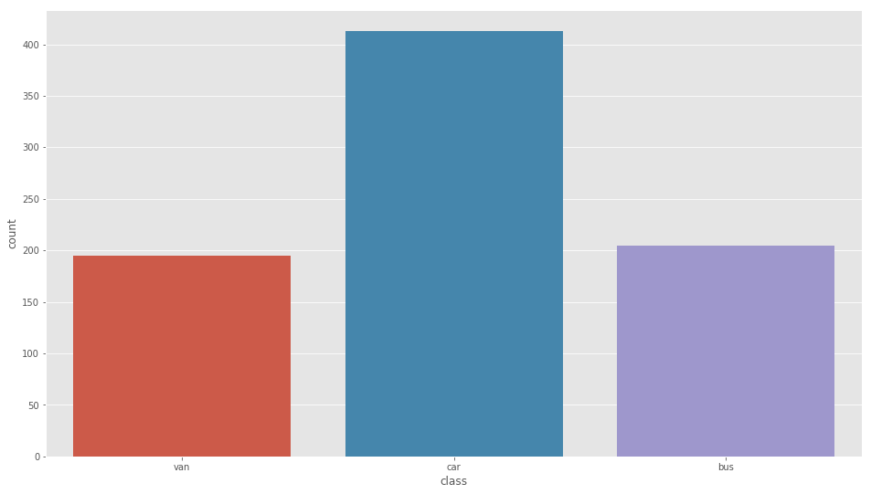

```python
sns.countplot(x='class', data=data1)
```

### Check for any missing values in the data

```python
data1.isnull().sum()
```

```
compactness                    0
circularity                    0
distance_circularity           0
radius_ratio                   0
pr.axis_aspect_ratio           0
max.length_aspect_ratio        0
scatter_ratio                  0
elongatedness                  0
pr.axis_rectangularity         0
max.length_rectangularity      0
scaled_variance                0
scaled_variance.1              0
scaled_radius_of_gyration      0
scaled_radius_of_gyration.1    0
skewness_about                 0
skewness_about.1               0
skewness_about.2               0
hollows_ratio                  0
class                          0
dtype: int64
```

### 3. Standardize the data

```python
from scipy.stats import zscore
```

Since the dimensions of the data are not really known to us, it would be wise to standardize the data using z scores before we go for any clustering methods. You can use zscore function to do this

```python
data_X=data1.drop('class',axis=1)
```

```python
data_Z=data_X.apply(zscore)
print (data_Z)
```

```
     compactness  circularity  distance_circularity  radius_ratio  \
0       0.163231     0.520408              0.060669      0.264970
1      -0.322874    -0.619123              0.124067     -0.836393
2       1.256966     0.845988              1.518823      1.187734
3      -0.079822    -0.619123             -0.002729     -0.300595
4      -1.052030    -0.130753             -0.763506      1.068668
6       0.406283    -0.293543             -0.573312      0.116137
7      -0.444400    -0.293543             -1.017098     -0.360128
8      -0.930504    -1.758654             -1.270690     -0.866160
10     -0.930504    -1.433074             -0.763506     -0.776860
11     -0.444400    -1.758654             -1.017098     -0.985226
12     -0.687452     0.194828             -0.509914      0.056604
13     -0.565926    -0.456333              0.187465     -0.747094
14      0.041705     0.683198             -0.192923      1.009135
15      0.284757     1.659939              1.328629      0.949602
```

[output cut: 364 more lines]

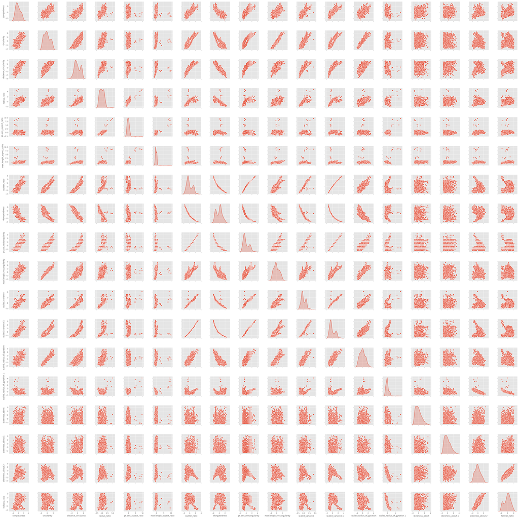

```python
sns.pairplot(data_Z, diag_kind='kde')
```

### 4. Plotting Elbow/ Scree Plot

```python
from sklearn.cluster import KMeans
from scipy.spatial import distance

# Let us check optimal number of clusters-
distortion = []

cluster_range = range( 1, 10)   # expect 3 to four clusters from the pair panel visual inspection hence restricting from 2 to 6
cluster_errors = []
cluster_sil_scores = []
for num_clusters in cluster_range:
  clusters = KMeans( num_clusters, n_init = 5)
  clusters.fit(data_Z)
  labels = clusters.labels_                     # capture the cluster lables
  centroids = clusters.cluster_centers_         # capture the centroids
  cluster_errors.append( clusters.inertia_ )    # capture the intertia
  distortion.append(sum(np.min(distance.cdist(data_Z, clusters.cluster_centers_, 'euclidean'), axis=1))/ data_Z.shape[0])
clusters_df = pd.DataFrame( { "num_clusters":cluster_range, "cluster_errors": cluster_errors } )
clusters_df[0:15]
```

|  | num_clusters | cluster_errors |
| --- | --- | --- |
| 0 | 1 | 14634.000000 |
| 1 | 2 | 8623.136976 |
| 2 | 3 | 7039.259060 |
| 3 | 4 | 5740.333282 |
| 4 | 5 | 5191.272069 |
| 5 | 6 | 4706.031064 |
| 6 | 7 | 4355.019229 |
| 7 | 8 | 4086.423524 |
| 8 | 9 | 3908.109963 |

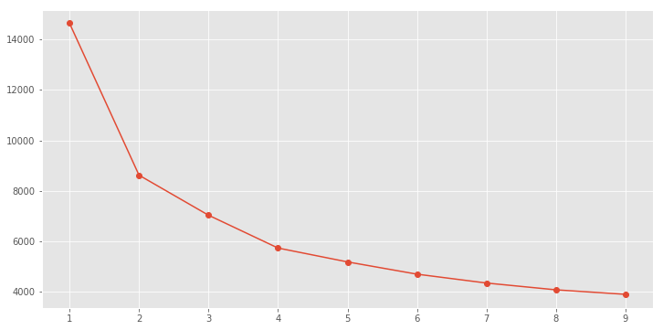

```python
# Elbow plot

plt.figure(figsize=(12,6))
plt.plot( clusters_df.num_clusters, clusters_df.cluster_errors, marker = "o" )
```

Use Matplotlib to plot the scree plot - Note: Scree plot plots distortion vs the no of clusters

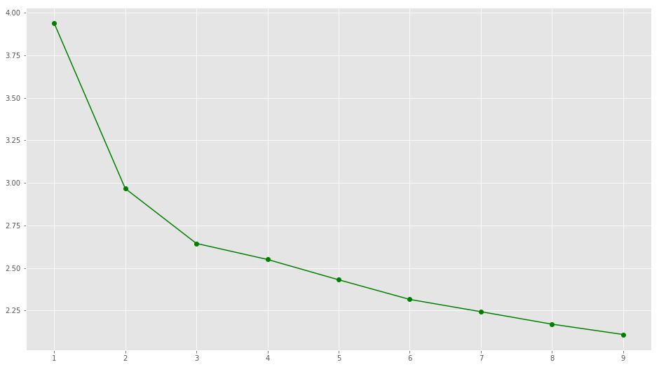

```python
plt.plot(range(1,10), distortion, 'go-')
```

### Find out the optimal value of K

```python
# After scrutiny of Pair plot, Elbow plot and Distortion plot, K value can be 2,3,4 . However, Optimal value of K is 3.
```

### Using optimal value of K - Cluster the data.

Note: Since the data has more than 2 dimension we cannot visualize the data. As an alternative, we can observe the centroids and note how they are distributed across different dimensions

```python
# Number of clusters

kmeans = KMeans(n_clusters=3)

# Fitting the input data

kmeans = kmeans.fit(data_Z)

# Getting the cluster labels

labels = kmeans.predict(data_Z)

# Centroid values

centroids = kmeans.cluster_centers_



# Comparing with scikit-learn centroids

print("Centroid values")

print(centroids) # From sci-kit learn
```

```
Centroid values
[[-0.91400071 -0.51327609 -0.88664922 -1.05602904 -0.49182906 -0.21883169
  -0.775563    0.85996991 -0.74203582 -0.47827281 -0.77910348 -0.78034412
  -0.37943428  0.82611912 -0.08658373 -0.30355495 -1.04650237 -1.10265258]
 [ 1.13076532  1.17094237  1.19500584  1.01909505  0.21505188  0.34250798
   1.27180461 -1.19061224  1.27548416  1.09266768  1.22038121  1.28132727
   1.07954232 -0.02879497  0.16229031  0.26566456 -0.00535553  0.18380067]
 [-0.2319252  -0.57973847 -0.30724438 -0.02693437  0.20516443 -0.11572895
  -0.45873352  0.32447256 -0.48810058 -0.54152679 -0.41282893 -0.46297248
  -0.60799507 -0.62342017 -0.06824398  0.01513248  0.82481456  0.71018194]]
```

You can use kmeans.cluster*centers* function to pull the centroid information from the instance

### 5. Store the centroids in a dataframe with column names from the original dataset given

```python
centroid_df = pd.DataFrame(centroids, columns = list(data_Z) )
centroid_df
```

[output not shown]

Hint: Use pd.Dataframe function

### Use kmeans.labels_ function to print out the labels of the classes

```python
prediction=kmeans.predict(data_Z)
data_Z["PREDICTEDGROUP"] = prediction     # Creating a new column "GROUP" which will hold the cluster id of each record
```

```python
kmeans.labels_
```

```
array([2, 2, 1, 2, 0, 2, 2, 2, 2, 2, 2, 2, 2, 1, 0, 2, 1, 0, 0, 2, 2, 1,
       2, 0, 1, 1, 0, 2, 2, 2, 1, 2, 0, 1, 1, 0, 1, 0, 0, 2, 1, 0, 0, 0,
       0, 2, 0, 2, 1, 2, 1, 2, 2, 0, 1, 0, 1, 0, 0, 0, 2, 0, 1, 2, 1, 1,
       2, 0, 2, 1, 2, 0, 0, 1, 2, 0, 2, 1, 2, 0, 2, 0, 1, 2, 1, 2, 0, 1,
       0, 0, 1, 0, 0, 2, 2, 0, 1, 1, 0, 0, 1, 2, 2, 0, 0, 0, 2, 1, 1, 2,
       0, 0, 2, 0, 0, 0, 0, 0, 2, 1, 1, 2, 2, 0, 1, 1, 0, 2, 0, 2, 2, 1,
       0, 2, 1, 2, 2, 2, 2, 1, 2, 2, 1, 2, 1, 2, 0, 2, 0, 1, 2, 2, 1, 1,
       2, 1, 0, 0, 1, 1, 2, 1, 2, 2, 2, 2, 0, 1, 0, 2, 0, 1, 2, 2, 2, 1,
       2, 1, 2, 1, 2, 0, 1, 0, 0, 0, 2, 2, 1, 1, 2, 2, 2, 0, 1, 2, 2, 2,
       1, 0, 0, 1, 0, 2, 1, 0, 0, 0, 2, 1, 2, 1, 0, 0, 0, 0, 1, 2, 0, 2,
       1, 0, 2, 2, 0, 1, 0, 0, 2, 2, 1, 0, 1, 0, 2, 2, 1, 2, 2, 1, 1, 0,
       2, 2, 2, 1, 0, 2, 2, 0, 0, 2, 2, 1, 2, 0, 0, 1, 2, 2, 0, 0, 1, 0,
       2, 1, 0, 2, 1, 2, 2, 1, 2, 1, 0, 2, 2, 1, 2, 2, 2, 0, 2, 1, 1, 1,
       1, 0, 2, 1, 0, 0, 0, 2, 0, 1, 1, 0, 1, 2, 0, 1, 0, 2, 2, 1, 1, 0,
       1, 1, 0, 1, 2, 2, 2, 0, 0, 1, 1, 1, 2, 2, 2, 1, 0, 2, 0, 1, 2, 2,
```

[output cut: 22 more lines]

## Hierarchical Clustering

### 6. Variable creation

For Hierarchical clustering, we will create datasets using multivariate normal distribution to visually observe how the clusters are formed at the end

a = np.random.multivariate_normal([10, 0], [[3, 1], [1, 4]], size=[100,]) b = np.random.multivariate_normal([0, 20], [[3, 1], [1, 4]], size=[50,]) c = np.random.multivariate_normal([10, 20], [[3, 1], [1, 4]], size=[100,])

```python
a = np.random.multivariate_normal([10, 0], [[3, 1], [1, 4]], size=[100,])
b = np.random.multivariate_normal([0, 20], [[3, 1], [1, 4]], size=[50,])
c = np.random.multivariate_normal([10, 20], [[3, 1], [1, 4]], size=[100,])
```

```python
a
```

```
array([[10.31223064, -0.78922801],
       [12.66208132,  2.19862584],
       [ 7.46340396,  0.25974091],
       [ 9.71154965,  0.83653322],
       [ 6.92143907, -0.48734513],
       [12.60632162,  0.55270293],
       [12.66653839,  3.42500334],
       [ 9.9781574 , -0.43413814],
       [ 6.85713825, -0.83195747],
       [10.14937012, -0.6972809 ],
       [ 5.21296963, -0.94256701],
       [ 9.68891902,  1.38925189],
       [10.22941819,  0.57048681],
       [ 9.08548737, -2.22742295],
       [ 8.25779926, -1.25770832],
       [ 8.29482639, -2.71330397],
       [ 9.38346208,  2.53731817],
       [ 9.6386751 ,  2.00516211],
       [10.59679587,  2.32308596],
       [ 9.52281457,  1.76974219],
       [10.58965405, -1.29132733],
       [11.0503765 , -3.71434927],
       [12.21290052,  1.52832403],
       [ 9.87562708, -0.16235755],
       [10.59023062, -1.48715837],
       [11.31120668,  2.16717574],
       [11.40337165,  3.76368213],
       [11.61836848, -2.63765304],
       [11.26683377, -2.15881069],
       [11.05330134, -1.73557435],
       [10.60302555, -1.68337781],
       [ 9.83110817, -1.41884608],
       [11.02383716, -1.12207337],
       [12.98213088, -1.99966848],
       [ 7.70140528, -1.10596158],
       [11.02332416, -2.59424565],
       [ 8.73935238, -1.37534052],
       [10.33527692, -0.201224  ],
       [11.69629924,  0.38770637],
       [12.33119982,  3.0148742 ],
```

[output cut: 45 more lines]

```
       [ 8.90944225, -1.49511618],
       [12.50000492, -0.87927534],
       [ 6.90004423, -2.98259712],
       [11.18605744,  0.20279511],
       [ 9.14243791, -0.4089194 ],
       [ 7.55909677, -2.35813834],
       [ 8.61336168, -2.17485274],
       [11.47901557, -1.6177958 ],
       [11.18491886, -0.49589219],
       [11.02506226,  0.97525004],
       [13.45058524,  0.18703095],
       [11.22706171,  3.24210853],
       [ 9.0119787 , -2.08296239],
       [ 9.56472956,  1.17557667],
       [11.44067607, -2.18744139]])
```

### 7. Combine all three arrays a,b,c into a dataframe

```python
hi_data=pd.DataFrame(np.concatenate ((a, b, c), axis=0),columns=list('AB'))
```

```python
hi_data
```

|  | A | B |
| --- | --- | --- |
| 0 | 10.312231 | -0.789228 |
| 1 | 12.662081 | 2.198626 |
| 2 | 7.463404 | 0.259741 |
| 3 | 9.711550 | 0.836533 |
| 4 | 6.921439 | -0.487345 |
| 5 | 12.606322 | 0.552703 |
| 6 | 12.666538 | 3.425003 |
| 7 | 9.978157 | -0.434138 |
| 8 | 6.857138 | -0.831957 |
| 9 | 10.149370 | -0.697281 |
| 10 | 5.212970 | -0.942567 |
| 11 | 9.688919 | 1.389252 |
| 12 | 10.229418 | 0.570487 |
| 13 | 9.085487 | -2.227423 |
| 14 | 8.257799 | -1.257708 |
| 15 | 8.294826 | -2.713304 |
| 16 | 9.383462 | 2.537318 |
| 17 | 9.638675 | 2.005162 |
| 18 | 10.596796 | 2.323086 |
| 19 | 9.522815 | 1.769742 |
| 20 | 10.589654 | -1.291327 |
| 21 | 11.050376 | -3.714349 |
| 22 | 12.212901 | 1.528324 |
| 23 | 9.875627 | -0.162358 |
| 24 | 10.590231 | -1.487158 |
| 25 | 11.311207 | 2.167176 |
| 26 | 11.403372 | 3.763682 |
| 27 | 11.618368 | -2.637653 |
| 28 | 11.266834 | -2.158811 |
| 29 | 11.053301 | -1.735574 |
| ... | ... | ... |
| 220 | 9.213675 | 18.942451 |
| 221 | 11.323967 | 20.235967 |
| 222 | 10.387903 | 20.487654 |
| 223 | 10.891014 | 21.072463 |
| 224 | 7.206928 | 21.468058 |
| 225 | 11.524988 | 20.754034 |
| 226 | 10.152676 | 18.431781 |
| 227 | 11.005966 | 19.707027 |
| 228 | 10.857997 | 21.272595 |
| 229 | 8.836520 | 17.874979 |
| 230 | 9.326698 | 20.066163 |
| 231 | 9.076743 | 16.600364 |
| 232 | 10.765499 | 19.686793 |
| 233 | 10.609971 | 19.278429 |
| 234 | 8.730671 | 18.684222 |
| 235 | 10.325316 | 19.796581 |
| 236 | 9.971347 | 23.551912 |
| 237 | 9.271769 | 20.709045 |
| 238 | 11.500563 | 19.375905 |
| 239 | 10.097094 | 20.909442 |
| 240 | 10.201964 | 23.093920 |
| 241 | 8.542736 | 20.697593 |
| 242 | 11.262450 | 21.212931 |
| 243 | 9.880765 | 16.758758 |
| 244 | 11.329800 | 19.304693 |
| 245 | 12.921581 | 20.726697 |
| 246 | 11.918872 | 22.029466 |
| 247 | 12.771725 | 20.656970 |
| 248 | 9.467766 | 16.614857 |
| 249 | 9.464447 | 22.813009 |

250 rows × 2 columns

### 8. Use scatter matrix to print all the 3 distributions

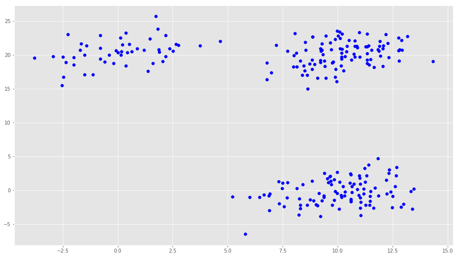

```python
plt.scatter(x=hi_data['A'], y=hi_data['B'], c='blue', alpha=1)
```

### 9. Find out the linkage matrix

```python
from scipy.cluster.hierarchy import cophenet, dendrogram, linkage
from scipy.spatial.distance import pdist  #Pairwise distribution between data points
```

Use ward as linkage metric and distance as Eucledian

```python
Z = linkage(hi_data, 'ward')
c, coph_dists = cophenet(Z , pdist(hi_data))

c
```

```
0.9604711627191849
```

### 10. Plot the dendrogram for the consolidated dataframe

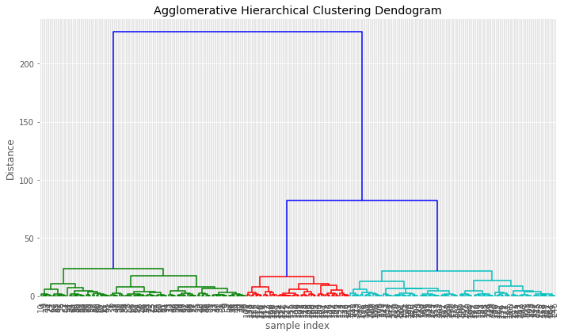

```python
plt.figure(figsize=(10, 6))
plt.title('Agglomerative Hierarchical Clustering Dendogram')
plt.xlabel('sample index')
plt.ylabel('Distance')
dendrogram(Z, leaf_rotation=90.,color_threshold=30,  leaf_font_size=10. )
plt.tight_layout()
```

### 11. Recreate the dendrogram for last 3 merged clusters

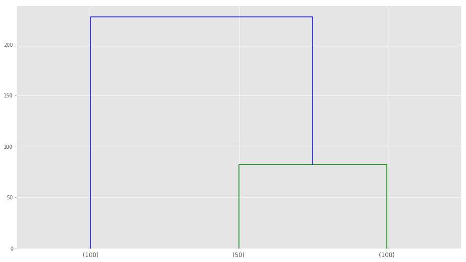

```python
dendrogram(
    Z,color_threshold=83,
    truncate_mode='lastp',  # show only the last p merged clusters
    p=3,  # show only the last p merged clusters
)
plt.show()
```

Hint: Use truncate_mode='lastp' attribute in dendrogram function to arrive at dendrogram

### 12. From the truncated dendrogram, find out the optimal distance between clusters which u want to use an input for clustering data

```python
# From the above Truncated Dendogram the optimal distance between clusters is 82.
```

### 13. Using this distance measure and fcluster function to cluster the data into 3 different groups

```python
from scipy.cluster.hierarchy import fcluster
```

```python
fcluster (Z, t=82, criterion='distance')
```

```
array([1, 1, 1, 1, 1, 1, 1, 1, 1, 1, 1, 1, 1, 1, 1, 1, 1, 1, 1, 1, 1, 1,
       1, 1, 1, 1, 1, 1, 1, 1, 1, 1, 1, 1, 1, 1, 1, 1, 1, 1, 1, 1, 1, 1,
       1, 1, 1, 1, 1, 1, 1, 1, 1, 1, 1, 1, 1, 1, 1, 1, 1, 1, 1, 1, 1, 1,
       1, 1, 1, 1, 1, 1, 1, 1, 1, 1, 1, 1, 1, 1, 1, 1, 1, 1, 1, 1, 1, 1,
       1, 1, 1, 1, 1, 1, 1, 1, 1, 1, 1, 1, 2, 2, 2, 2, 2, 2, 2, 2, 2, 2,
       2, 2, 2, 2, 2, 2, 2, 2, 2, 2, 2, 2, 2, 2, 2, 2, 2, 2, 2, 2, 2, 2,
       2, 2, 2, 2, 2, 2, 2, 2, 2, 2, 2, 2, 2, 2, 2, 2, 2, 2, 3, 3, 3, 3,
       3, 3, 3, 3, 3, 3, 3, 3, 3, 3, 3, 3, 3, 3, 3, 3, 3, 3, 3, 3, 3, 3,
       3, 3, 3, 3, 3, 3, 3, 3, 3, 3, 3, 3, 3, 3, 3, 3, 3, 3, 3, 3, 3, 3,
       3, 3, 3, 3, 3, 3, 3, 3, 3, 3, 3, 3, 3, 3, 3, 3, 3, 3, 3, 3, 3, 3,
       3, 3, 3, 3, 3, 3, 3, 3, 3, 3, 3, 3, 3, 3, 3, 3, 3, 3, 3, 3, 3, 3,
       3, 3, 3, 3, 3, 3, 3, 3], dtype=int32)
```

### Use matplotlib to visually observe the clusters in 2D space

```python
labels = fcluster (Z, t=82, criterion='distance')
```

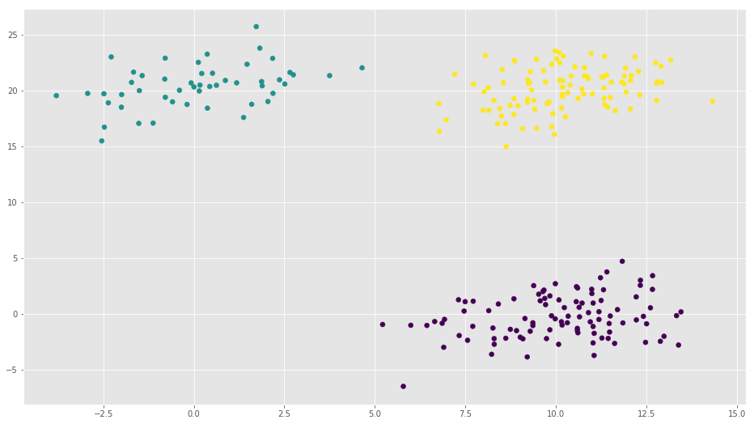

```python
plt.scatter(x=hi_data['A'], y=hi_data['B'], c=labels)
```